# Make GPS Dataset

Hannah Moshontz

2021-03-01

### Notes

Purpose: This script creates the analysis gps dataset and conducts eda.

Inputs:

- participants’ raw gps data files

Outputs

- gps.csv

### Setup

Packages and Source

```r
library(tidyverse)
library(purrr)
library(readxl)
library(janitor)
library(geosphere)
library(lubridate)
library(plotKML)
library(janitor)
library(psych)
library(kableExtra)
library(readxl)
library(data.table)
library(ggplot2)
```

Paths

```r
path_data <- "./analysis/shared/data"
```

### Functions

Function to import and standardize moves data

```r
convert_moves <- function(file_name){

  message('......loading: ', file_name)

  d_moves <- readGPX(file_name,
                     metadata = FALSE, bounds = FALSE,
                     waypoints = TRUE, tracks = TRUE, routes = FALSE) %>%
    .$tracks %>%
    purrr::flatten(.) %>% # as a list of dfs
    enframe(.) %>% # as a nested df
    unnest(keep_empty = TRUE) %>% # as one tibble
    rename(long = lon) #renaming for coherence


  if (
    any(is.na(d_moves$time) & !(is.na(d_moves$lat) & is.na(d_moves$long)))
  ) stop("Missing value detected for time on non-missing day")

  # drop initial missing obs and impute time for missing obs and
  # fill in the last second of the next day;  Retain time zone from previous observation
  d_moves <- d_moves %>%
    fill(time) %>%
    mutate(time = if_else(is.na(long),
                          str_c(lubridate::mdy(name),
                                "T23:59:59.000-",
                                str_extract(time, "\\d{2}:\\d{2}$")),
                          time)) %>%
    select(-name) %>%
    mutate(time = as_datetime(time, tz = 'America/Chicago')) %>%
    arrange(time) %>% #sort on time
    mutate(
      data_type = 'gps',
      speed_kmh = NA,
      altitude_meters = NA,
      direction = NA,
      accuracy = NA,
      app_source = 'moves',
      count = NA
    ) %>%
    select(lat, long, time, accuracy, sgmnt_type, trckpnt_type,
           app_source, data_type, speed_kmh, altitude_meters,
           direction, count)

  return(d_moves)
}
```

Function to import and standardize followmee data

```r
convert_followmee <- function(file_name){

  #multiple GPX exist for 52 58 59 63 64 65 66 76 77 78 79 80 81 82
  message('......Loading: ', file_name)

  d_followmee <- read_rds(file_name) %>%
    clean_names("snake") %>%
    mutate(
      raw_orig_time = date,
      time = as_datetime(date, tz = 'America/Chicago')
    ) %>%  # convert time to dttm
    arrange(time) %>%
    mutate(
      lat = latitude,
      long = longitude,
      data_type = str_to_lower(type),
      speed_kmh = speed_km_h,
      altitude_meters = altitude_m,
      app_source = 'followmee',
      count = NA,
      sgmnt_type = NA,
      trckpnt_type = NA
    ) %>%
    select(lat, long, time, accuracy, sgmnt_type, trckpnt_type,
           app_source, data_type, speed_kmh, altitude_meters,
           direction, count)

  return(d_followmee)

}
```

Function to make the final gps rds (calls previous functions)

```r
make_gps <- function(subid) {

  raw_file <- str_c("./raw_data/", subid)
  location_file <- str_c("./raw_data/", subid, "/", subid, "_Locations.xlsx")
  subid_numeric <- as.numeric(subid)

  message('...importing gps for subject ', subid)

  # list gpx files
  gpx_files <- list.files(
    path = raw_file,
    pattern = '.gpx',
    full.names = TRUE,
    recursive = FALSE,
    include.dirs = FALSE
  )

  # list followmee files
  followmee_files <- list.files(
    path = raw_file,
    pattern = '\\d{3}_GPSFollowRaw.rds',
    full.names = TRUE,
    recursive = FALSE,
    include.dirs = FALSE
  )

  #store type of gps data source
  only_gpx <- ifelse(length(gpx_files) >= 1 &
                       length(followmee_files) == 0,
                     TRUE, FALSE)

  only_followmee <- ifelse(length(gpx_files) == 0 &
                             length(followmee_files) == 1,
                           TRUE, FALSE)

  both <- ifelse(length(gpx_files) >= 1 &
                   length(followmee_files) == 1,
                 TRUE, FALSE)

  gps_absent <- !xor(xor(only_gpx, only_followmee), both)

  #create empty dfs
  d_moves <- NULL
  d_follow <- NULL

  #process and save gpx (accommodates multiple)
  if (length(gpx_files) != 0) {

    d_moves <- map_df(gpx_files, ~convert_moves(.x)) %>% #import, convert, bind each file
      filter(!is.na(long), !is.na(lat)) %>% #drop obs without lat and long
      distinct() #eliminate fully duplicated rows
  }


  #process and save followmee file
  if (length(followmee_files) == 1) {

    d_follow <- convert_followmee(followmee_files[1])
  }

  if (!gps_absent) { #if subject has gps data, create the dataset and return
    #create database rds
    database <- bind_rows(d_moves, d_follow) %>%
      arrange(time) %>%
      select(-count) %>% #this is NA for all
      filter(!is.na(lat) && !is.na(long)) %>%
      mutate(subid = subid_numeric)

    return(database)
  }
}
```

### Creating the gps data

Store subids

```r
subid_all <- list.dirs("./raw_data", recursive = FALSE) %>%
  str_extract("\\d{3}$") %>%
  na.exclude()
```

Create and save the gps data

```r
map_dfr(subid_all, ~make_gps(.x)) %>%
  write_csv(., file = file.path(path_data, "gps.csv"))
```

## EDA

### Import Data and glimpse()

GPS data

```r
gps <- fread(file.path(path_data, "gps.csv"), #need fread because data is huge, crashes r otherwise
             stringsAsFactors = TRUE) %>%
  mutate(raw_orig_time = as.character(time)) %>%
  glimpse()
```

```
## Rows: 1,240,944
## Columns: 13
## $ lat             <dbl> 43.07284, 43.07284, 43.07284, 43.07284, 43.07284, 43.0~
## $ long            <dbl> -89.40627, -89.40627, -89.40627, -89.40627, -89.40627,~
## $ time            <dttm> 2017-03-01 15:47:24, 2017-03-01 18:03:11, 2017-03-01 ~
## $ accuracy        <int> NA, NA, NA, NA, NA, NA, NA, NA, NA, NA, NA, NA, NA, NA~
## $ sgmnt_type      <fct> place, place, place, place, place, move, move, move, m~
## $ trckpnt_type    <fct> unknown, walking, walking, walking, unknown, transport~
## $ app_source      <fct> moves, moves, moves, moves, moves, moves, moves, moves~
## $ data_type       <fct> gps, gps, gps, gps, gps, gps, gps, gps, gps, gps, gps,~
## $ speed_kmh       <int> NA, NA, NA, NA, NA, NA, NA, NA, NA, NA, NA, NA, NA, NA~
## $ altitude_meters <int> NA, NA, NA, NA, NA, NA, NA, NA, NA, NA, NA, NA, NA, NA~
## $ direction       <int> NA, NA, NA, NA, NA, NA, NA, NA, NA, NA, NA, NA, NA, NA~
## $ subid           <int> 1, 1, 1, 1, 1, 1, 1, 1, 1, 1, 1, 1, 1, 1, 1, 1, 1, 1, ~
## $ raw_orig_time   <chr> "2017-03-01 15:47:24", "2017-03-01 18:03:11", "2017-03~
```

```r
notes <- read_csv("./raw_data/raw_notes.csv")

visit_dates <- read_csv(file.path(path_data, "visit_dates.csv"))
```

There are 167 subjects contributing 1240944 gps observations.

We have gps-specific notes from staff on 101 subjects.

### Checking each data source

#### Lat and long

```r
gps %>%
  filter(is.na(lat) | is.na(long))
```

```
## Empty data.table (0 rows and 13 cols): lat,long,time,accuracy,sgmnt_type,trckpnt_type...
```

This is not surprising. We filtered on NA lat / long (one of the apps would create a missing point if no signals were detected in a day).

```r
gps %>%
  filter(lat <= 1 & long <= 1, lat >= -1 & long >= -1)
```

```
## Empty data.table (0 rows and 13 cols): lat,long,time,accuracy,sgmnt_type,trckpnt_type...
```

There are no “Null Island” points at 0,0.

#### Time

```r
gps %>%
  filter(is.na(time))
```

```
##         lat      long time accuracy sgmnt_type trckpnt_type app_source
## 1: 43.07086 -89.52392 <NA>       NA      place gym_training      moves
## 2: 43.07015 -89.52365 <NA>       NA      place gym_training      moves
## 3: 43.01351 -89.47709 <NA>       NA      place gym_training      moves
##    data_type speed_kmh altitude_meters direction subid raw_orig_time
## 1:       gps        NA              NA        NA    54          <NA>
## 2:       gps        NA              NA        NA    54          <NA>
## 3:       gps        NA              NA        NA    58          <NA>
```

**Potential errors**

There are three observations where there is a location but no time. Consider removing these.

#### Accuracy, speed, altitude, direction

```r
gps %>%
  select(accuracy, speed_kmh, altitude_meters, direction) %>%
  describe()
```

```
##                 vars      n   mean     sd median trimmed    mad   min   max
## accuracy           1 623363  22.48  74.12     10   14.86   7.41     1 12258
## speed_kmh          2 519077  32.54  40.18     10   26.33  14.83     0  1039
## altitude_meters    3 569079 272.90 209.86    261  258.92  34.10 -3517 12566
## direction          4 406431 175.75 105.33    178  175.55 133.43     0   358
##                 range  skew kurtosis   se
## accuracy        12257 29.31  1800.65 0.09
## speed_kmh        1039  2.03    22.01 0.06
## altitude_meters 16083 21.71   885.16 0.28
## direction         358  0.00    -1.15 0.17
```

#### Data type

```r
gps %>%
  tabyl(data_type, app_source, show_na = TRUE) %>%
  adorn_totals(c("row", "col")) %>%
  kable() %>%
  kable_styling(full_width = FALSE, position = "left", bootstrap_options = "condensed")
```

| data_type | followmee | moves | Total |
| --- | --- | --- | --- |
| gps | 622435 | 617581 | 1240016 |
| network | 928 | 0 | 928 |
| Total | 623363 | 617581 | 1240944 |

The vast majority of gps observations were labeled as gps as opposed to network-type observations. Only followmee produced network-type observations.

#### App source

```r
gps %>%
  tabyl(app_source, show_na = TRUE) %>%
  adorn_totals("row") %>%
  kable() %>%
  kable_styling(full_width = FALSE, position = "left", bootstrap_options = "condensed")
```

| app_source | n | percent |
| --- | --- | --- |
| followmee | 623363 | 0.5023297 |
| moves | 617581 | 0.4976703 |
| Total | 1240944 | 1.0000000 |

About half of observations came from each app.

### Number of Observations per Person

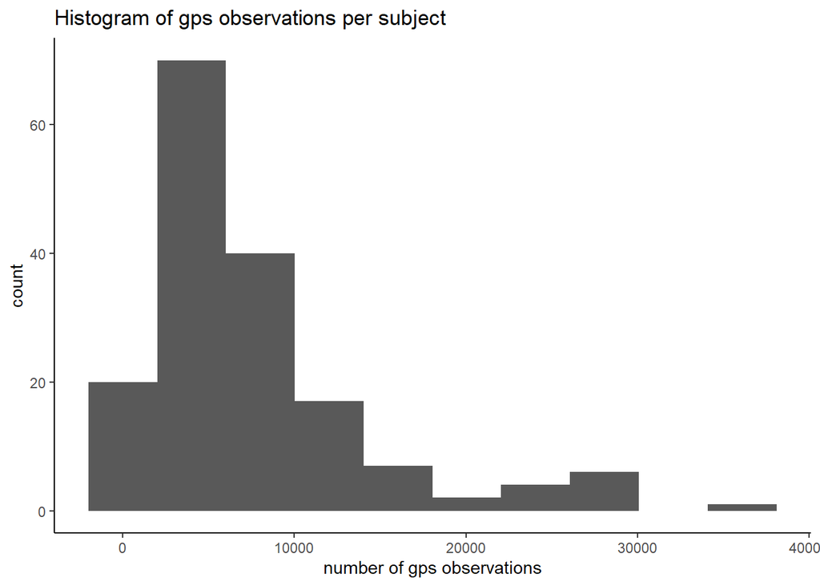

```r
gps %>%
  group_by(subid) %>%
  summarise(n_obs = n()) %>%
  ggplot(aes(x = n_obs)) +
  geom_histogram(bins = 10) +
  xlab("number of gps observations") +
  ggtitle("Histogram of gps observations per subject") +
  theme_classic()
```

### Number of Observations per Non-Missing Day

```r
mean_avg_obs_per_day <- gps %>%
  mutate(date_central = date(time)) %>%
  group_by(subid, date_central) %>%
  summarise(n_obs = n()) %>%
  group_by(subid) %>%
  summarise(avg_obs_per_day = mean(n_obs)) %>%
  .$avg_obs_per_day %>%
  mean()

max_obs_per_day <- gps %>%
  mutate(date_central = date(time)) %>%
  group_by(subid, date_central) %>%
  summarise(n_obs = n()) %>%
  group_by(subid) %>%
  summarise(avg_obs_per_day = mean(n_obs),
            sd = sd(n_obs),
            min = min(n_obs),
            max = max(n_obs)) %>%
  .$max %>% max()
```

On average, participants provided an average of 93.9739152 observations per non-missing day (max = 2307).

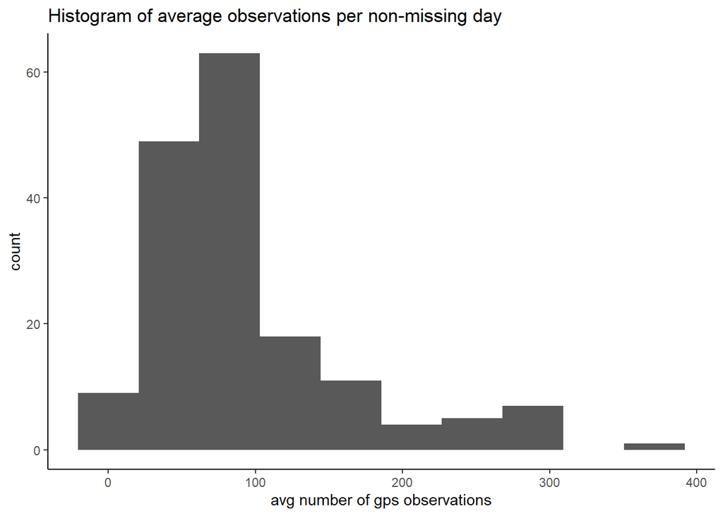

```r
gps %>%
  mutate(date_central = date(time)) %>%
  group_by(subid, date_central) %>%
  summarise(n_obs = n()) %>%
  group_by(subid) %>%
  summarise(avg_obs_per_day = mean(n_obs),
            min = min(n_obs),
            max = max(n_obs)) %>%
  ggplot(aes(x = avg_obs_per_day)) +
  geom_histogram(bins = 10) +
  xlab("avg number of gps observations") +
  ggtitle("Histogram of average observations per non-missing day") +
  theme_classic()
```